# Annual Report Data Analysis - Question 3.12

Tristan Burgess and Cristin Young

2026-03-18

# 3. Did EBP/CDEP services impact clinical and functional outcomes for clients who participated?

## 3.12 To what extent did parents/caregivers report a reduction in parent-related stress after receiving the intervention?

**Definition:** PSS item(s) measuring reduction in parent/caregiver-related stress after the intervention. Assessments showing improvement from pre- to post-time point for clients who discharged from an intervention during the designated time frame.

**Scoring:** If follow-up is LOWER than initial, that indicates a positive outcome. To calculate a total PSS score, items 1, 2, 5, 6, 7, 8, 17, and 18 should be reverse scored as follows: (1=5) (2=4) (3=3) (4=2) (5=1). The PSS score is then obtained by summing across all items. Higher scores indicate higher levels of perceived stress. If follow-up is LOWER than initial, that indicates a positive outcome.

- 1 = Strongly disagree
- 2 = Disagree
- 3 = Undecided
- 4 = Agree
- 5 = Strongly Agree

**Assumptions:** Filtered out dates before 2024-01-01 and after the date the code was run. Filtered data that’s >3 days from initial assessment and paired to the LAST follow-up. Filtered positive outcomes that had NAs before computing %. Total score = NA if 2+ items are missing; used LAST follow-up if 2+ assessments exist; filtered out NA’s from follow-up date and positive outcome variable before calculating %.

**Range:** 18 - 90

**Inclusion Criteria:** 1. must have initial time point data (i.e., be enrolled in an intervention); 2. must have a valid assessment collected at both initial and discharge comparison time points

**Final analysis:** Regression - outcome = binary (4/5 vs other), predictors as for 3.01

```
 positive_outcome   n percent
               -1 143     14%
                0  45      4%
                1 819     81%
```

Plot it.

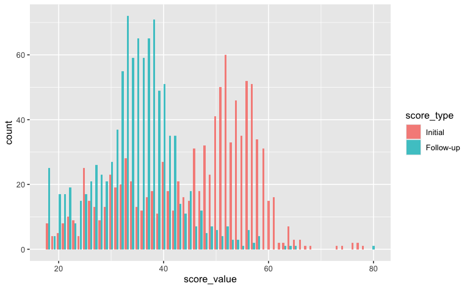

Ridgeline plot

| score_type | mean_score | median_score | sd_score | n | y_text |
| --- | --- | --- | --- | --- | --- |
| Initial | 45.50645 | 49 | 11.811042 | 1007 | 1.085 |
| Follow-up | 34.88679 | 35 | 7.858787 | 1007 | 1.080 |

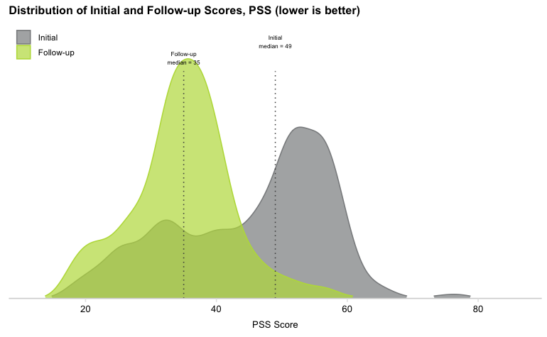